# Data Science Capstone Milestone Report

Joe Fuqua

December 16, 2015

This is an interim report describing my progress in performing the Capstone project for the Johns Hopkins Data Science Certification program. At this stage I have successfully obtained the data sets to be analyzed, performed basic data structuring and cleansing, and conducted a preliminary analysis of the data.

# Sourcing the Data

The data files have been downloaded and unpacked to a local directory on my PC.

There are three separate directories of three separate files; for this analysis I will focus solely on the English files:

- en_US.blogs.txt
- en_US.news.txt
- en_US.twitter.txt

I will load a sample of each of the English files for initial analysis, but first I’ll load libraries that we’ll need:

```r
library(R.utils)
library(tm)
library(rJava)
library(RWeka)
```

Some basic stats for each file (file size and number of lines):

blogs.txt:

```r
file.size('final/en_US/en_US.blogs.txt')
```

```
## [1] 210160014
```

```r
countLines('final/en_US/en_US.blogs.txt')
```

```
## [1] 899288
## attr(,"lastLineHasNewline")
## [1] TRUE
```

news.txt:

```r
file.size('final/en_US/en_US.news.txt')
```

```
## [1] 205811889
```

```r
countLines('final/en_US/en_US.news.txt')
```

```
## [1] 1010242
## attr(,"lastLineHasNewline")
## [1] TRUE
```

twitter.txt:

```r
file.size('final/en_US/en_US.twitter.txt')
```

```
## [1] 167105338
```

```r
countLines('final/en_US/en_US.twitter.txt')
```

```
## [1] 2360148
## attr(,"lastLineHasNewline")
## [1] TRUE
```

So now we have a sense of the size of the data files we’re dealing with.

Given the fact that these are large datasets, I’ll load the first 1000 records of each of the three English language files so that I can perform some initial exploratory analysis.

Let’s take a quick look at average wordcounts per line for each sample dataset:

blogs.txt:

```
## [1] 41.89
```

news.txt:

```
## [1] 33.489
```

twitter.txt:

```
## [1] 12.782
```

Next, we’ll tokenize the text then purge non-alpha characters and profanity.

# Data Cleansing

First, let’s merge datasets and filter undesired characters & text:

```r
merged <- paste(samp_blogs,samp_news,samp_twitter)
merged_corpus <- Corpus(VectorSource(merged))
```

Time to clean up (remove punctuation, numbers, convert to lower to simplify analysis):

```r
merged_corpus<-tm_map( merged_corpus,tolower)
merged_corpus<-tm_map(merged_corpus,removePunctuation)
merged_corpus<-tm_map(merged_corpus,removeNumbers)
merged_corpus<-tm_map(merged_corpus,stripWhitespace)
```

Okay, now for profanity, I found a list of profane phrases at: http://www.bannedwordlist.com/lists/swearWords.txt

I downloaded the file and will load into R and run against the corpus:

```r
profane_list<-read.table('swearWords.txt',sep='\n')
merged_corpus<-tm_map(merged_corpus, removeWords, profane_list$V1)
```

# Exploring the Data

Okay, let’s build some tokenized lists:

Single Groupings:

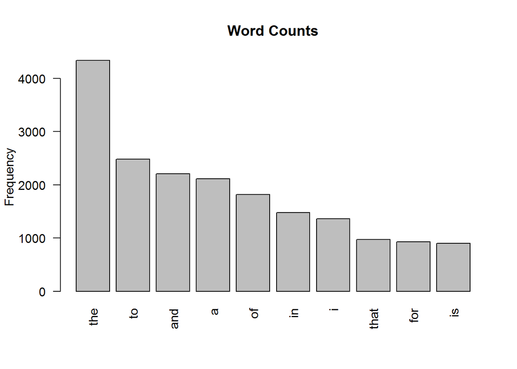

```r
mc1 <- NGramTokenizer(merged_corpus, Weka_control(min = 1, max = 1))
mc1_data <- data.frame(table(mc1))
mc1_data <- mc1_data[order(mc1_data$Freq,decreasing = TRUE),]

barplot(mc1_data[1:10,'Freq'],names.arg=mc1_data[1:10,'mc1'], las=2, main='Word Counts', ylab='Frequency')
```

Paired Groupings:

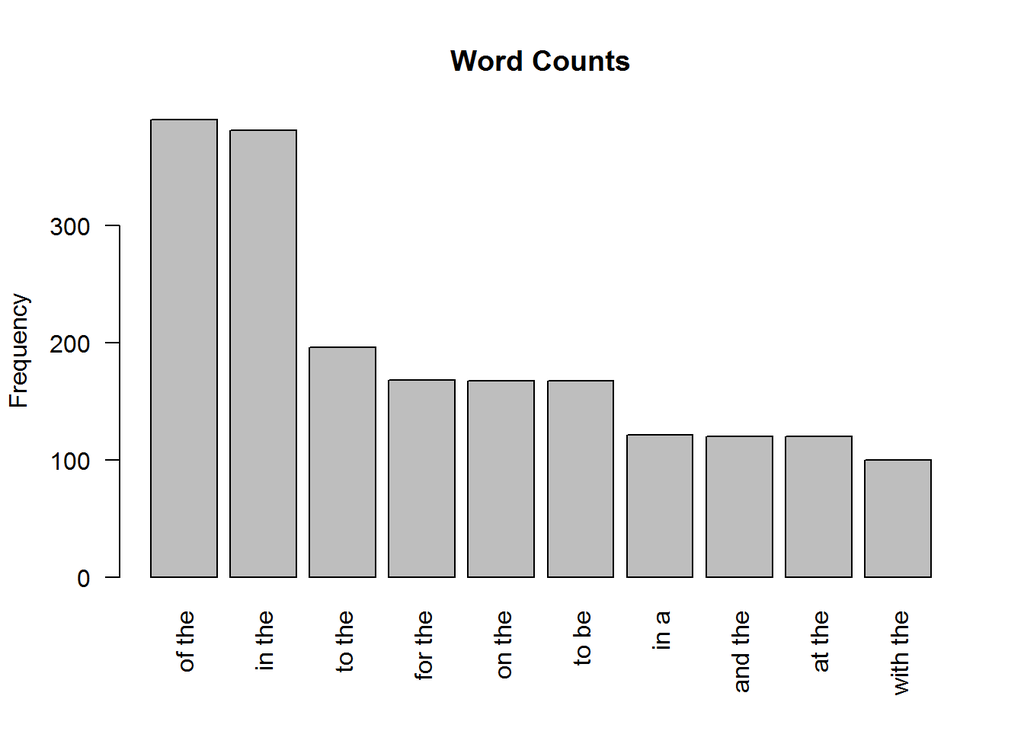

```r
mc2 <- NGramTokenizer(merged_corpus, Weka_control(min = 2, max = 2))
mc2_data <- data.frame(table(mc2))
mc2_data <- mc2_data[order(mc2_data$Freq,decreasing = TRUE),]

barplot(mc2_data[1:10,'Freq'],names.arg=mc2_data[1:10,'mc2'], las=2, main='Word Counts', ylab='Frequency')
```

Triplets:

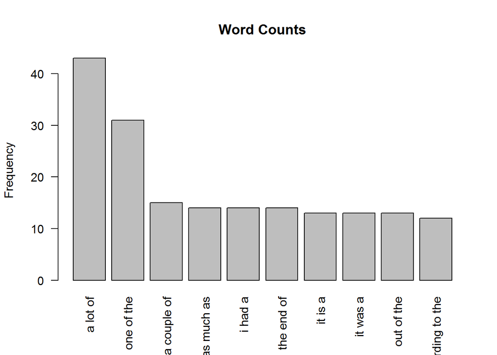

```r
mc3 <- NGramTokenizer(merged_corpus, Weka_control(min = 3, max = 3))
mc3_data <- data.frame(table(mc3))
mc3_data <- mc3_data[order(mc3_data$Freq,decreasing = TRUE),]

barplot(mc3_data[1:10,'Freq'],names.arg=mc3_data[1:10,'mc3'], las=2, main='Word Counts', ylab='Frequency')
```

# Conclusions and Follow Up

So, now we have a good feel for the data, how to cleanse it, and how to manipulate it. The next step will be to build a predictive model using a random sample of the merged datasets and to produce the final, consumable report.